# Experimental treatment with edaravone in a mouse model of spinocerebellar ataxia 1

Cognitive functions in water T-maze

Author

Martina Sucha, Simona Benediktova, Filip Tichanek, Jan Jedlicka, Stepan Kapl, Dana Jelinkova, Zdenka Purkartova, Jan Tuma, Jitka Kuncova, Jan Cendelin

This page shows R code for the study [Sucha et al.](https://www.mdpi.com/1422-0067/24/13/10689) (2023, *International Journal of Molecular Science*).

**Citation**:

> Sucha M, Benediktova S, Tichanek F, Jedlicka J, Kapl S, Jelinkova D, Purkartova Z, Tuma J, Kuncova J, Cendelin J. Experimental Treatment with Edaravone in a Mouse Model of Spinocerebellar Ataxia 1. International Journal of Molecular Sciences. 2023; 24(13):10689. https://doi.org/10.3390/ijms241310689

[GitHub page](https://github.com/filip-tichanek/edaravonSCA1): https://github.com/filip-tichanek/edaravonSCA1

# 1 Upload of packages

```r
rm(list = ls())

suppressWarnings(suppressMessages( {
library(brms)
library(beeswarm)
library(vioplot)
library(glmmTMB)
library(car)
library(cowplot)
library(ggplot2)
library(tidyverse)
library(bayesplot)
library(gtsummary)
library(vegan)
library(knitr)
library(ggplot2)
  } ) )
```

# 2 Data upload and wrangling

```r
load("source_data/myEnvironment.RData")

## obtining number of correct turns (from 4 trials) as outcome of T-maze
behav[,which(grepl("t_session", colnames(behav)))] <- (behav[,which(grepl("t_session", colnames(behav)))]/100)*4

## defining mean succees per T-maze session
behav$tmaze_tot <- rowMeans(behav[
  ,which(grepl("t_session", colnames(behav)))])

## getting numbers of correct turns per 3 sessions
behav <- behav %>% mutate(
  t_q1 = t_session1 + t_session2 + t_session3,
  t_q2 = t_session4 + t_session5 + t_session6,
  t_q3 = t_session7 + t_session8 + t_session9,
  t_q4 = t_session10 + t_session11 + t_session12,
  t_ntrials = 12,

## getting #success turns in the last 2 sessions
  t_last2 = t_session11 + t_session12) %>% mutate(

## numbers of success in 1 half (learning phase)
  t_a = t_q1 + t_q2,

## numbers of success in the 2nd phase (flexibility)
  t_b = t_q3 + t_q4,

## number of success in training sessions
  t_aq = t_q1 + t_q3,

## number of success in training sessions (definition #2)
  t_test = t_q2 + t_q4,
  t_test2 = t_q2 + t_last2)

## long format
t_data <- behav[,which(grepl("t_session", colnames(behav)))]
t_data <- data.frame(t_data, id = as.factor(behav$id), group = behav$group, sex = behav$sex)
dat_long <- gather(t_data, key = "session", value = "value",
                   starts_with("t_session"), na.rm = TRUE)
dat_long <- separate(dat_long, session, c("prefix", "session"), sep = "t_session")
dat_long$correct <- dat_long$value/4
dat_long$corr_perc <- dat_long$correct * 100
dat_long$session <- as.numeric(dat_long$session)

## subseting learning (1st half of experiment) and flexibility (reversal) parts
dat_long_learn <- subset(dat_long, session < 7)
dat_long_flex <- subset(dat_long, session > 6)

summary(dat_long)
```

```
       id           group     sex        prefix             session
 7      : 12   ctrl.wt :240   f:468   Length:960         Min.   : 1.00
 9      : 12   eda.wt  :240   m:492   Class :character   1st Qu.: 3.75
 11     : 12   ctrl.sca:240           Mode  :character   Median : 6.50
 12     : 12   eda.sca :240                              Mean   : 6.50
 13     : 12                                             3rd Qu.: 9.25
 14     : 12                                             Max.   :12.00
 (Other):888
     value          correct         corr_perc
 Min.   :0.000   Min.   :0.0000   Min.   :  0.00
 1st Qu.:1.000   1st Qu.:0.2500   1st Qu.: 25.00
 Median :2.000   Median :0.5000   Median : 50.00
 Mean   :2.139   Mean   :0.5346   Mean   : 53.46
 3rd Qu.:4.000   3rd Qu.:1.0000   3rd Qu.:100.00
 Max.   :4.000   Max.   :1.0000   Max.   :100.00
```

# 3 Data exploration

! In following plots, blue vertical line imply the change of the position of hidden platform. Thus, from that point, animals must forget already known and flexibly re-learn to another position (implying cognitive flexibility)

## 3.1 Mean success (%) across groups and sexes

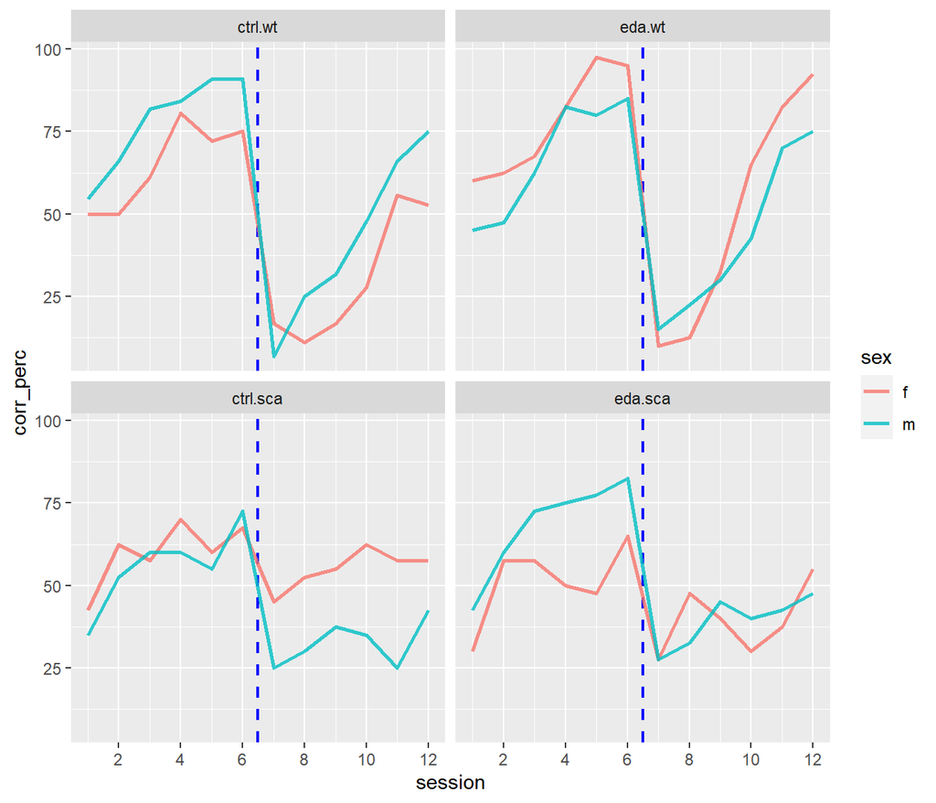

```r
dat_long %>%
  ggplot(aes(
    x=session, y=corr_perc, by=id, col=sex, group=interaction(group, sex)
    )) +
  geom_vline(xintercept = 6.5,
                color = "blue", linewidth=0.8, linetype= 'dashed') +
  stat_summary(fun = "mean", geom = "line", alpha = 0.8, size = 1) +
  facet_wrap(~group)+
  scale_x_continuous(breaks = seq(2, max(dat_long$session), by = 2))
```

There is no consistent effect of sex. Sex will be ignored

## 3.2 Average values over groups

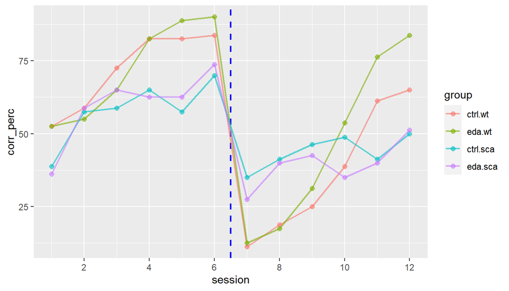

```r
dat_long %>%
  ggplot(aes(
    x=session, y=corr_perc, by=id, group=group, col=group
    )) +
  geom_vline(xintercept = 6.5,
                color = "blue", linewidth=0.8, linetype= 'dashed') +
  stat_summary(fun = "mean", geom = "line", alpha = 0.6, size = 0.8)+
  stat_summary(fun = "mean", geom = "point", alpha = 0.6, size = 2)+
  scale_x_continuous(breaks = seq(2, max(dat_long$session), by = 2))
```

You can see that genotype clearly matters. As expected, SCA1 mice show worse learning. This lead to paradoxical situation: when the position of the platform change (requiring forgetting the previously acquired information) WT mice show worse result due to SCA1 mice did not learn well (less need to forget). You can see that 4 another sessions are needed for WT mice to re-learn and show again better results compared to SCA1 mice.

This complicates the analysis and interpretation of the second half of the experiment. To address this, we will do following:

- 1. although we originally divided sessions to ‘acquisition’ vs. ‘testing’ in the way that half of each phase (learning vs. flexibility) were ‘acquisition’ (sessions 1-3 and 7-9) and second halves were ‘testing’ (4-6 and 10-12), we will modify the definition of testing and only last two sessions of the ‘flexibility’ phase will be considered as ‘testing’. Thus,
  - ‘acquisition’: sessions 1-3 and 7-10
  - ‘testing’: sessions 4-6 and 11-12
- 2. as there still may be effect of site preference or absence of learning in the first phase, flexibility (proportion of correct turns in the sessions 11-12) will be modelled via two models, where the 2nd will include success in the 7th session as a covariate

# 4 Modelling

We will construct 4 models

- 1. across testing sessions of learning phase, sessions 4-6 (*initial learning*)
- 2. across testing sessions of flexibility phase, sessions 11-12 (*flexibility*)
- 3. across testing sessions of flexibility phase, sessions 11-12, but with the covariate of success on 7th session

- 4. model of successive turns across all testing sessions (4-6 and 11-12, *all testing sessions*)

As we have presumably overdispersed binomial data, we will use beta-binomial likelihood

## 4.1 Defining function for beta-binomial distribution

```r
beta_binomial2 <- custom_family(
  "beta_binomial2", dpars = c("mu", "phi"),
  links = c("logit", "log"), lb = c(NA, 2),
  type = "int", vars = "vint1[n]")

stan_funs <- "
real beta_binomial2_lpmf(int y, real mu, real phi, int T) {
    return beta_binomial_lpmf(y | T, mu * phi, (1 - mu) * phi);
  }
  int beta_binomial2_rng(real mu, real phi, int T) {
    return beta_binomial_rng(T, mu * phi, (1 - mu) * phi);
  }
"
stanvars <- stanvar(scode = stan_funs, block = "functions")
```

## 4.2 Setting priors

```r
behav$group<-relevel(behav$group,ref='ctrl.sca')

logit(mean(behav$t_q2/12))
```

```
[1] 1.104176
```

```r
logit(mean(behav$t_q4/12))
```

```
[1] 0.1502822
```

```r
logit(mean(behav$t_test/24))
```

```
[1] 0.5939495
```

```r
## initial learning model
prior1 <- c(set_prior("student_t(3, 1.1, 5)", class = "b", coef = "Intercept"),
            set_prior("normal(0,2)", class = "b", coef = "groupctrl.wt"),
            set_prior("normal(0,2)", class = "b", coef = "groupeda.wt"),
            set_prior("normal(0,1.2)"  , class = "b", coef = "groupeda.sca"))

## flexibility models
prior2 <- c(set_prior("student_t(3, 0.15, 5)", class = "b", coef = "Intercept"),
            set_prior("normal(0,2)", class = "b", coef = "groupctrl.wt"),
            set_prior("normal(0,2)", class = "b", coef = "groupeda.wt"),
            set_prior("normal(0,1.2)"  , class = "b", coef = "groupeda.sca"))


prior3 <- c(set_prior("student_t(3, 0.15, 5)", class = "b", coef = "Intercept"),
            set_prior("normal(0,2)", class = "b", coef = "groupctrl.wt"),
            set_prior("normal(0,2)", class = "b", coef = "groupeda.wt"),
            set_prior("normal(0,1.2)"  , class = "b", coef = "groupeda.sca"),
            set_prior("normal(0.5,1)", class = "b", coef = "t_session7"))

## all testing sessions model
prior4 <- c(set_prior("student_t(3, 0.6, 5)", class = "b", coef = "Intercept"),
            set_prior("normal(0,2)", class = "b", coef = "groupctrl.wt"),
            set_prior("normal(0,2)", class = "b", coef = "groupeda.wt"),
            set_prior("normal(0,1.2)"  , class = "b", coef = "groupeda.sca"))
```

## 4.3 Fitting the models and convergence and ESS check

```r
## initial learning
t_model1 <- run_model(
          brm(t_q2|vint(12) ~ 0 + Intercept + group,
                 data = behav,
                 stanvars = stanvars,
                 prior= prior1,
                 family=beta_binomial2,
                 save_pars = save_pars(all = TRUE),
                 iter=8000, warmup=2000,chains=2,cores=1,seed=17,
                 control = list(adapt_delta = 0.99)),
                 'output/brm/t_model1', reuse = TRUE)

## flexibility, unadjusted
t_model2 <- run_model(
          brm(t_last2|vint(8) ~ 0 + Intercept + group,
                 data = behav,
                 stanvars = stanvars,
                 prior= prior2,
                 family=beta_binomial2,
                 save_pars = save_pars(all = TRUE),
                 iter=8000, warmup=2000,chains=2,cores=1,seed=17,
                 control = list(adapt_delta = 0.99)),
                 'output/brm/t_model2', reuse = TRUE)

## flexibility, adjusted
t_model3 <- run_model(
          brm(t_last2|vint(8) ~ 0 + t_session7 + Intercept + group,
                 data = behav,
                 stanvars = stanvars,
                 prior= prior3,
                 family=beta_binomial2,
                 save_pars = save_pars(all = TRUE),
                 iter=8000, warmup=2000,chains=2,cores=1,seed=17,
                 control = list(adapt_delta = 0.99)),
                 'output/brm/t_model3', reuse = TRUE)

## all testing sessions
t_model4 <- run_model(
          brm(t_test2|vint(20) ~ 0 +  Intercept + group,
                 data = behav,
                 stanvars = stanvars,
                 prior= prior4,
                 family=beta_binomial2,
                 save_pars = save_pars(all = TRUE),
                 iter=8000, warmup=2000,chains=2,cores=1,seed=17,
                 control = list(adapt_delta = 0.99)),
                 'output/brm/t_model4', reuse = TRUE)


summary(t_model1)
```

```
 Family: beta_binomial2
  Links: mu = logit; phi = identity
Formula: t_q2 | vint(t_ntrials) ~ 0 + Intercept + group
   Data: behav (Number of observations: 80)
  Draws: 2 chains, each with iter = 8000; warmup = 2000; thin = 1;
         total post-warmup draws = 12000

Population-Level Effects:
             Estimate Est.Error l-95% CI u-95% CI Rhat Bulk_ESS Tail_ESS
Intercept        0.62      0.26     0.11     1.15 1.00     4004     5107
groupctrl.wt     0.96      0.40     0.18     1.75 1.00     4980     6272
groupeda.wt      1.20      0.42     0.40     2.03 1.00     5028     6256
groupeda.sca     0.03      0.36    -0.68     0.74 1.00     4542     6385

Family Specific Parameters:
    Estimate Est.Error l-95% CI u-95% CI Rhat Bulk_ESS Tail_ESS
phi     2.89      0.58     2.07     4.26 1.00     4996     3221

Draws were sampled using sampling(NUTS). For each parameter, Bulk_ESS
and Tail_ESS are effective sample size measures, and Rhat is the potential
scale reduction factor on split chains (at convergence, Rhat = 1).
```

```r
summary(t_model2)
```

```
 Family: beta_binomial2
  Links: mu = logit; phi = identity
Formula: t_last2 | vint(t_ntrials) ~ 0 + Intercept + group
   Data: behav (Number of observations: 80)
  Draws: 2 chains, each with iter = 8000; warmup = 2000; thin = 1;
         total post-warmup draws = 12000

Population-Level Effects:
             Estimate Est.Error l-95% CI u-95% CI Rhat Bulk_ESS Tail_ESS
Intercept       -0.91      0.24    -1.39    -0.45 1.00     3346     4755
groupctrl.wt     0.54      0.32    -0.11     1.17 1.00     4118     5258
groupeda.wt      1.00      0.31     0.39     1.63 1.00     3941     5686
groupeda.sca     0.01      0.32    -0.62     0.65 1.00     3910     5142

Family Specific Parameters:
    Estimate Est.Error l-95% CI u-95% CI Rhat Bulk_ESS Tail_ESS
phi     5.34      1.33     3.30     8.41 1.00     6899     6059

Draws were sampled using sampling(NUTS). For each parameter, Bulk_ESS
and Tail_ESS are effective sample size measures, and Rhat is the potential
scale reduction factor on split chains (at convergence, Rhat = 1).
```

```r
summary(t_model3)
```

```
 Family: beta_binomial2
  Links: mu = logit; phi = identity
Formula: t_last2 | vint(8) ~ 0 + t_session7 + Intercept + group
   Data: behav (Number of observations: 80)
  Draws: 2 chains, each with iter = 8000; warmup = 2000; thin = 1;
         total post-warmup draws = 12000

Population-Level Effects:
             Estimate Est.Error l-95% CI u-95% CI Rhat Bulk_ESS Tail_ESS
t_session7       0.50      0.14     0.23     0.79 1.00     5524     7139
Intercept       -0.80      0.33    -1.47    -0.15 1.00     3452     5063
groupctrl.wt     1.09      0.42     0.29     1.93 1.00     4599     6453
groupeda.wt      1.92      0.44     1.06     2.81 1.00     4204     5910
groupeda.sca     0.06      0.39    -0.72     0.83 1.00     4905     6334

Family Specific Parameters:
    Estimate Est.Error l-95% CI u-95% CI Rhat Bulk_ESS Tail_ESS
phi     2.31      0.28     2.01     3.07 1.00     5681     3369

Draws were sampled using sampling(NUTS). For each parameter, Bulk_ESS
and Tail_ESS are effective sample size measures, and Rhat is the potential
scale reduction factor on split chains (at convergence, Rhat = 1).
```

```r
summary(t_model4)
```

```
 Family: beta_binomial2
  Links: mu = logit; phi = identity
Formula: t_test2 | vint(20) ~ 0 + Intercept + group
   Data: behav (Number of observations: 80)
  Draws: 2 chains, each with iter = 8000; warmup = 2000; thin = 1;
         total post-warmup draws = 12000

Population-Level Effects:
             Estimate Est.Error l-95% CI u-95% CI Rhat Bulk_ESS Tail_ESS
Intercept        0.29      0.19    -0.07     0.66 1.00     4242     5844
groupctrl.wt     0.87      0.29     0.32     1.44 1.00     5019     7060
groupeda.wt      1.33      0.30     0.76     1.93 1.00     5224     6499
groupeda.sca     0.03      0.26    -0.48     0.53 1.00     4753     6815

Family Specific Parameters:
    Estimate Est.Error l-95% CI u-95% CI Rhat Bulk_ESS Tail_ESS
phi     7.00      1.64     4.33    10.80 1.00     8410     6272

Draws were sampled using sampling(NUTS). For each parameter, Bulk_ESS
and Tail_ESS are effective sample size measures, and Rhat is the potential
scale reduction factor on split chains (at convergence, Rhat = 1).
```

Model converged well (RHat values = 1), ESSs are sufficient (>2000).

Given binomial outcome and beta-binomial likelihood distribution, PPC will not be provided (there is available function for this and there is less need for PPC in binomial data)

## 4.4 Extraction of posterior draws

```r
## learning
post_fix_learn <- as.data.frame(t_model1, variable = c("b_Intercept","b_groupctrl.wt",
                                             "b_groupeda.wt","b_groupeda.sca"))
names(post_fix_learn)[1]<-"sca_ctrl"

post_fix_learn$wt_ctrl<-post_fix_learn$sca_ctrl+post_fix_learn$b_groupctrl.wt
post_fix_learn$wt_eda<-post_fix_learn$sca_ctrl+post_fix_learn$b_groupeda.wt
post_fix_learn$sca_eda<-post_fix_learn$sca_ctrl+post_fix_learn$b_groupeda.sca
post_fix_learn$wt_contrast<-post_fix_learn$wt_eda-post_fix_learn$wt_ctrl



post_fix_flex <- as.data.frame(t_model3, variable = c("b_Intercept","b_groupctrl.wt",
                                                        "b_groupeda.wt","b_groupeda.sca"))
names(post_fix_flex)[1]<-"sca_ctrl"

post_fix_flex$wt_ctrl<-post_fix_flex$sca_ctrl+post_fix_flex$b_groupctrl.wt
post_fix_flex$wt_eda<-post_fix_flex$sca_ctrl+post_fix_flex$b_groupeda.wt
post_fix_flex$sca_eda<-post_fix_flex$sca_ctrl+post_fix_flex$b_groupeda.sca
post_fix_flex$wt_contrast<-post_fix_flex$wt_eda-post_fix_flex$wt_ctrl


post_fix_tot <- as.data.frame(t_model4, variable = c("b_Intercept","b_groupctrl.wt",
                                                       "b_groupeda.wt","b_groupeda.sca"))
names(post_fix_tot)[1]<-"sca_ctrl"

post_fix_tot$wt_ctrl<-post_fix_tot$sca_ctrl+post_fix_tot$b_groupctrl.wt
post_fix_tot$wt_eda<-post_fix_tot$sca_ctrl+post_fix_tot$b_groupeda.wt
post_fix_tot$sca_eda<-post_fix_tot$sca_ctrl+post_fix_tot$b_groupeda.sca
post_fix_tot$wt_contrast<-post_fix_tot$wt_eda-post_fix_tot$wt_ctrl


groupquant<-sapply(post_fix_tot[,c(5,6,1,7)],function(p) quantile(p, probs = c(0.025,0.975,0.5)))
groupquant <- inv.logit(groupquant)
```

# 5 Visualization

## 5.1 Showing data

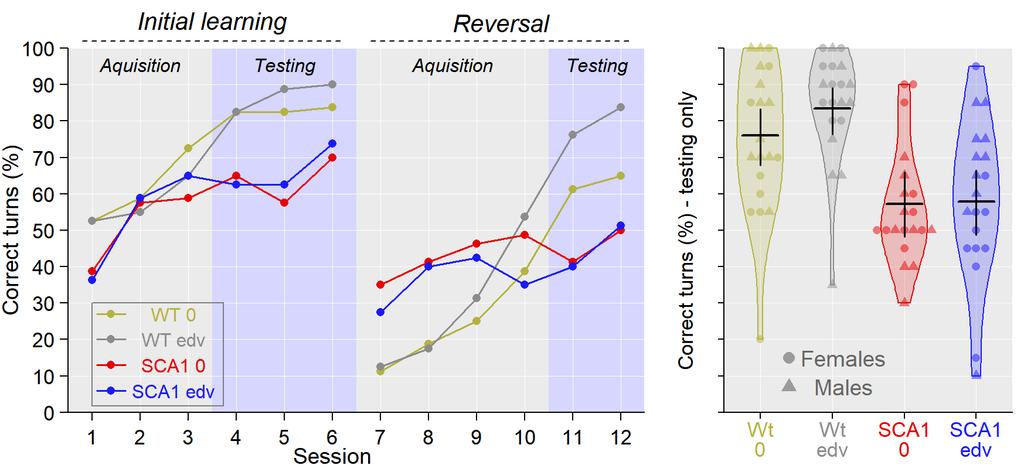

```r
dat_long$group <- factor(dat_long$group,levels = c('ctrl.wt','eda.wt','ctrl.sca','eda.sca') )

m= matrix(c(1,2), nrow = 1, ncol=2, byrow = TRUE)
layout(mat = m, heights = c(1),
       widths = c(0.75, 0.4))

par(mar=c(2,2,1.5,0))
par(mgp=c(1,0.6,0))
range<-c(0, 100);scal<-range[2]-range[1]
xrange<-c(0.5,12.5);xscal=xrange[2]-xrange[1]
plot(NULL,xlim=c(xrange[1],xrange[2]),ylim=c(range[1],range[2]),xlab="",
     ylab="Correct turns (%)",las=1, axes=FALSE,cex.lab=1.2)

rect(xrange[1],range[2],xrange[2],range[1],col="grey92",border=NA)

rect(3.5,range[2],6.5,range[1],col = rgb(0.84,0.84,1),border=NA)
rect(10.5,range[2],12.5,range[1],col = rgb(0.84,0.84,1),border=NA)


x<-range[1]
repeat{
  lines(c(xrange[1],xrange[2]),c(x,x),col="white",lwd=0.7)
  x=x+10;if(x>range[2]){break}}

x<-1
repeat{
  lines(c(x,x),c(range[1],range[2]),col="white",lwd=0.7)
  x=x+1;if(x>12){break}}


tap_dat <- tapply(dat_long$corr_perc, list(
  dat_long$session, dat_long$group), mean)


xl <- c(1:6)
for (x in 1:4){
  lines(tap_dat[1:6,x] ~xl ,col=cola[x], lwd = 1.9, type = 'o', pch= 16)
}

xl <- c(7:12)
for (x in 1:4){
  lines(tap_dat[7:12,x] ~xl ,col=cola[x], lwd = 1.9, type = 'o', pch= 16)
}


tckk=-0.02

axis(2,las=2,cex.axis=1.1,at=seq(range[1],range[2],by=10),pos=xrange[1]
     ,tck=tckk)

axis(side=1,las=1,cex.axis=1.1, at=c(1:12),,pos=range[1],tck=tckk)
lines(c(0.5,12.5), c(0,0))

text(6, range[1]-0.117*scal, 'Session', xpd= TRUE, cex=1.2)



x = 1
y = 27; yde <- 7
lines(c(1.1,1.7),c(y,y), col = cola[x], pch = 16, lwd = 1.9)
text(2.7, y, 'WT 0', col = cola[x])
points(1.4, y, pch = 16, col = cola[x]); x = x+1; y = y-yde

lines(c(1.1,1.7),c(y,y), col = cola[x], pch = 16, lwd = 1.9)
text(2.7, y, 'WT edv', col = cola[x])
points(1.4, y, pch = 16, col = cola[x]); x = x+1; y = y-yde

lines(c(1.1,1.7),c(y,y), col = cola[x], pch = 16, lwd = 1.9)
text(2.7, y, 'SCA1 0', col = cola[x])
points(1.4, y, pch = 16, col = cola[x]); x = x+1; y = y-yde

lines(c(1.1,1.7),c(y,y), col = cola[x], pch = 16, lwd = 1.9)
text(2.7, y, 'SCA1 edv', col = cola[x])
points(1.4, y, pch = 16, col = cola[x]); x = x+1; y = y-yde

rect(1,30,3.74,1.8, col=NULL, border = "grey50")

text(c(2,5,8.5,11.5),c(rep(95,4)),
     c("Aquisition","Testing","Aquisition", "Testing"),font = 3)

text(c(3.5,9.5),c(rep(107,2)),c("Initial learning","Reversal"),
     font = 3, cex = 1.3, xpd=TRUE)

lines(c(0.8,6.2),c(102,102),lty=2)
lines(c(6.8,12.2),c(102,102),lty=2)

### 2nd plot -----------
par(mgp=c(0.7,0.6,0))
behav$group<-factor(behav$group,levels=c('ctrl.wt','eda.wt','ctrl.sca','eda.sca'))
xrange<-c(0.5,4.5);xscal=xrange[2]-xrange[1]
plot(NULL,xlim=c(xrange[1],xrange[2]),ylim=c(range[1],range[2]),xlab="",
     ylab="Correct turns (%) - testing only",las=1, axes=FALSE,cex.lab=1.1)

rect(xrange[1],range[2],xrange[2],range[1],col="grey92",border=NA)
x<-range[1]
repeat{
  lines(c(xrange[1],xrange[2]),c(x,x),col="white",lwd=0.7)
  x=x+10;if(x>range[2]){break}}

x<-1
repeat{
  lines(c(x,x),c(range[1],range[2]),col="white",lwd=0.7)
  x=x+1;if(x>4.5){break}}

vioplot(100*(behav$t_test2/20) ~ behav$group,col=colb,at=c(1:4),add=T,
        border=cola,axes=FALSE,drawRect=F,lwd=1,wex=0.8)

beeswarm(100*(behav$t_test2/20) ~ behav$group,
         col=colc,at=c(1:4),add=T,pwpch=(16.5+behav$sex_num) )

groupquant <- groupquant*100
tp<-(groupquant[3,])
xx<-1;wid=0.25
repeat{
  lines(c(xx-wid,xx+wid),c(tp[xx],tp[xx]),lwd=2,col="black");
  lines(c(xx,xx),c(groupquant[1,xx],groupquant[2,xx]),lwd=1.7,col="black")
  xx<-xx+1
  if(xx>4){break}}

tckk=-0.02
axis(2,las=2,cex.axis=1.1,at=seq(range[1],range[2],by=10),
     labels=c(rep("",length(seq(range[1],range[2],by=10)))),
     pos=xrange[1],tck=tckk)


axis(side=1,las=1,cex.axis=1.1,at=c(seq(1,4,by=1)),
     labels=c(rep("",length(seq(1,4,by=1)))),pos=range[1],tck=tckk)
lines(c(xrange[1],xrange[2]),c(range[1],range[1]))
text(c(1:4),c(rep(range[1]-0.046*scal,4)),xpd=T,cex=1.1,col=cola,
     c("Wt","Wt", "SCA1", "SCA1"))
ypo<-c(range[1]-0.1*scal,range[1]-0.1*scal)
text(c(1:4),c(ypo[1],ypo[2],ypo[1],ypo[2]),xpd=T,cex=1.1,col=cola,
     c("0","edv", "0", "edv"))

ypos<-15;xpos=1.4
points(xpos,ypos,pch=16,cex=1.4,col=rgb(0.4,0.4,0.4,alpha=0.6))
text(xpos+0.19*xscal,ypos,"Females",col="grey40",cex=1.2)
points(xpos,ypos-0.08*scal,pch=17,cex=1.4,col=rgb(0.4,0.4,0.4,alpha=0.6))
text(xpos+0.19*xscal,ypos-0.08*scal,"Males",col="grey40",cex=1.2)
```

## 5.2 Posterior distributions for the effect - log [Odds Ratio]

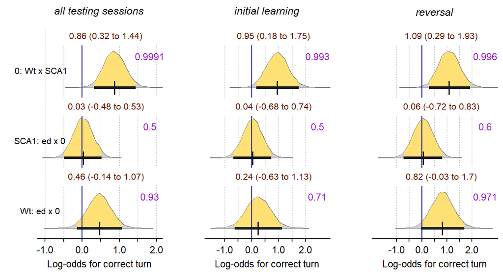

```r
m= matrix(c(1,2,3,
            4,5,6), nrow = 2, ncol=3, byrow = TRUE)
layout(mat = m, heights = c(0.07, 0.93),
       widths = c(1/3, 1/3, 1/3))

par(mar=c(0,0,0,0))
par(mgp=c(0,0.0,0))

plot(NULL, xlim=c(-1,1), ylim=c(-1,1), axes=F)
text(0.2,-0.20,"all testing sessions", cex = 1.2, font = 3,xpd=TRUE)


plot(NULL, xlim=c(-1,1), ylim=c(-1,1), axes = F)
text(0.2,-0.2,"initial learning", cex = 1.2, font = 3,xpd=TRUE)

plot(NULL, xlim=c(-1,1), ylim=c(-1,1), axes = F)
text(0.2,-0.2,"reversal", cex = 1.2, font = 3,xpd=TRUE)


par(mar=c(3,3,0,0))
par(mgp=c(2,0.6,0))

dif<-data.frame(post_fix_tot$wt_contrast,post_fix_tot$b_groupeda.sca,
                post_fix_tot$b_groupctrl.wt)
dif<- (dif)

yla<-"Log-odds for correct turn"
tckk=-0.018
ste<-seq(-1,2,by=0.5)
mons_poste(dif, 0)

zpos=seq(0,1,1/3)
xx=1;ind=0.4;xpol<- -1.1
text(xpol,zpos[xx]+zpos[2]*ind,
     "Wt: ed x 0 ",cex=1,xpd=TRUE)
xx=xx+1

text(xpol,zpos[xx]+zpos[2]*ind,
     "SCA1: ed x 0 ",cex=1,xpd=TRUE)
xx=xx+1

text(xpol,zpos[xx]+zpos[2]*ind,
     "0: Wt x SCA1",cex=1,xpd=TRUE)


dif<-data.frame(post_fix_learn$wt_contrast,post_fix_learn$b_groupeda.sca,
                post_fix_learn$b_groupctrl.wt)
dif<- (dif)

yla<-"Log-odds for correct turn"
tckk=-0.018
ste<-seq(-1,2,by=0.5)
mons_poste(dif, 0)


dif<-data.frame(post_fix_flex$wt_contrast,post_fix_flex$b_groupeda.sca,
                post_fix_flex$b_groupctrl.wt)
dif<- (dif)

yla<-"Log-odds for correct turn"
tckk=-0.018
ste<-seq(-1,2,by=0.5)
mons_poste(dif, 0)
```